# R Notebook

## Análisis del rendimiento estadístico de jugadores y campeones en LOL

=======================================================================================

## 1. Introducción

=======================================================================================

### Objetivo Principal

- Analizar las variables que mejor describen el comportamiento y rendimiento de los campeones y jugadores respectivamente.

### Objetivos Secundarios

1. Determinar la relación entre la variable “KDA” y el porcentaje de victorias.
2. Comprobar una relación existente entre el porcentaje de muertes de un jugador y el porcentaje de daño que realiza a los enemigos.
3. Encontrar la influencia de la variable “súbditos por minuto” en el porcentaje oro generado.
4. Corroborar si tener un número alto de asistencias determina un menor porcentaje de victorias.

### Muestreo

La base de datos usada para este proyecto viene de algunos datos capturados previamente del campeonato de Europa de League of Legens 2019, el cual fue publicado por Stephen O’Farrel. En este caso se trabajará con 2 datas Frame. El primero es el “lec_championdata” el cual tiene como unidad muestral al campeón. El segundo viene a ser el “lec_playerdata” el cual tiene como unidad muestral a los jugadores agrupados por equipo.

Se cargan las librerías correspondientes

```r
library(readr)
library(dplyr)
library(stringr)
library(data.table)
```

### Modelos de variables aleatorias en el estudio

A continuación se adjunta una tabla con los modelos de variables aleatorias posibles para algunas de las variables de estudio:

- Variable kills “K”: Bernoulli
- Variable “KDA” : Discreta
- Variable posición “Pos”: Geométrica
- Variable porcentaje de victorias “%W” : Discreta
- Variable Súbditos por minuto “CSPM” : Discreta
- Variable porcentaje de oro “Gold%” : Discreta
- Variable porcentaje de daño “DMG%” : Discreta
- Variable porcentaje de muertes “DTH%” : Discreta

Se asignan las bases de datos del “campeón” y del “jugador” a analizar a DF1 y DF2 respectivamente.

```r
DF1 <- read_csv("lec_championdata.csv")
```

```
## -------------------------------------------------------- Delimiter: "," chr
## (8): Champion 1, <25 winrate, 25-30 winrate, 30-35 winrate, 35-40 winra... dbl
## (26): ...1, 0, ∑ 2, W 3, L 4, WR 5, ∑ 6, W 7, L 8, WR 9, ∑ 10, W 11, L 1...
```

```r
DF2 <- read_csv("lec_playerdata.csv")
```

```
## -------------------------------------------------------- Delimiter: "," chr
## (4): Player, Team, Pos, Split dbl (21): ...1, GP, W%, K, D, A, KDA, KP, DTH%,
## FB%, GD10, XPD10, CSD10, CSP...
```

=======================================================================================

## 2. Análisis Descriptivo

=======================================================================================

## 2.1 Variable KDA

```r
summary(DF2$KDA)
```

```
##    Min. 1st Qu.  Median    Mean 3rd Qu.    Max.
##   0.300   2.200   3.000   3.748   4.200  40.000
```

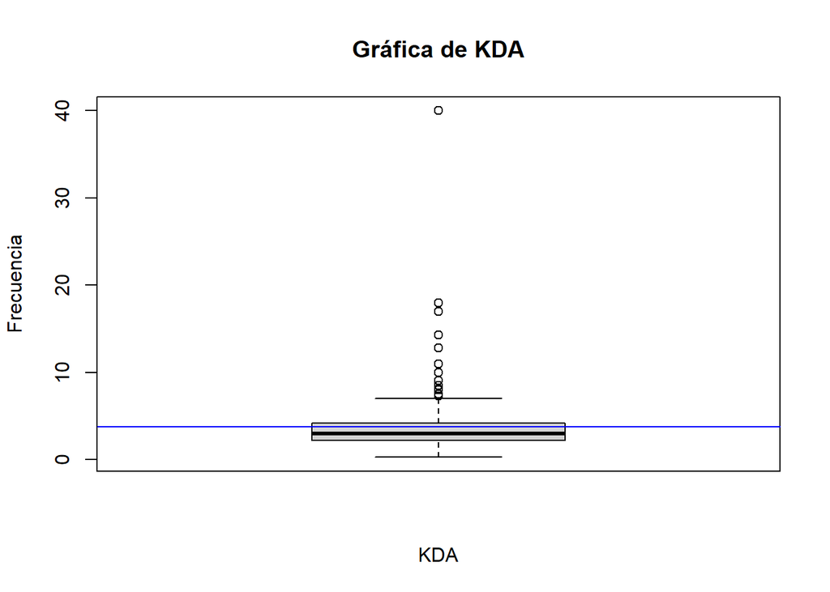

```r
boxplot(DF2$KDA, main = "Gráfica de KDA",xlab="KDA",ylab="Frecuencia")
abline(h=mean(DF2$KDA),col="blue",lwd=1)
```

Análisis: La variable KDA determina el nivel de habilidad de cada jugador, esta no es mas que la suma de las kills y asistencias realizadas entre el número de muertes. Es lógico ver valores atípicos, extremadamente altos, debido a jugadores “genios” o a la gran diferencia de nivel entre equipos participantes.

### 2.2 Variable porcentaje de muerte y porcentaje de daño

```r
summary(DF2$`DTH%`)
```

```
##    Min. 1st Qu.  Median    Mean 3rd Qu.    Max.
##    0.00   16.30   20.00   19.77   23.50   50.00
```

```r
summary(DF2$`DMG%`)
```

```
##    Min. 1st Qu.  Median    Mean 3rd Qu.    Max.
##    5.40   12.70   22.50   19.96   26.10   47.90
```

Análisis: Se obtiene como media del porcentaje de muertes 20 ,y la media para el porcentaje de daño 20 de igual forma. No se evidencia una gran diferencia entre la mediana y los extremos de la variable para este caso.

### 2.3 Variable Súbditos por minuto (CSPM)

```r
summary(DF2$CSPM)
```

```
##    Min. 1st Qu.  Median    Mean 3rd Qu.    Max.
##    0.70    4.40    7.70    6.39    8.90   11.00
```

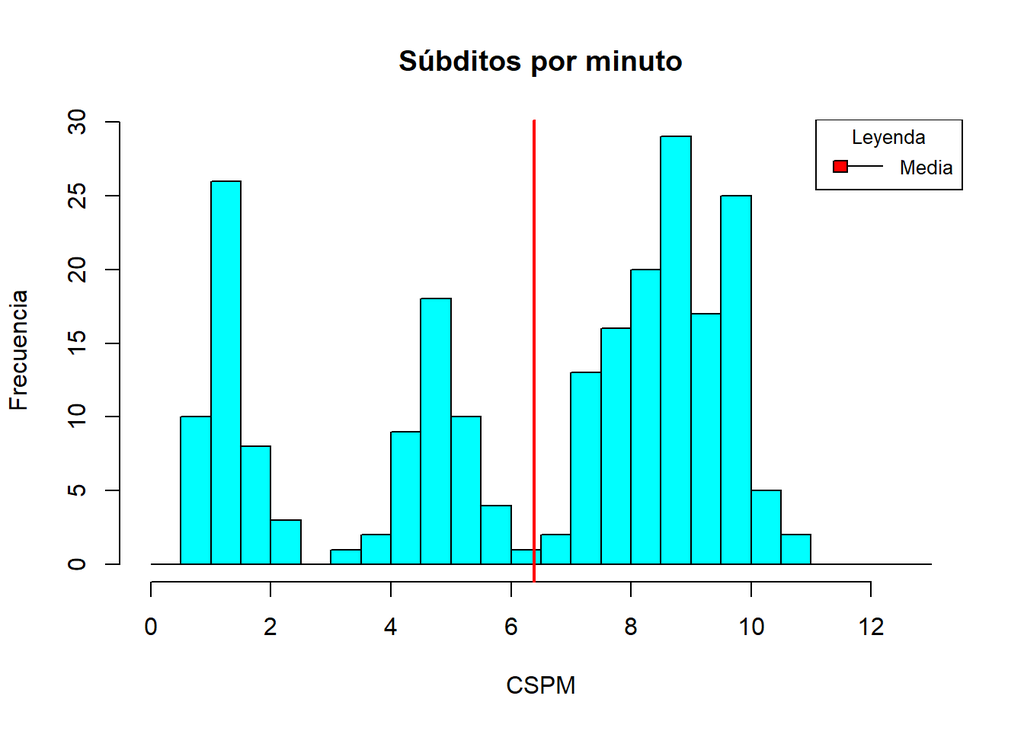

```r
hist(DF2$CSPM,breaks=seq(from=0,to=max(DF2$CSPM)+2,by=0.5),main="Súbditos por minuto",xlab="CSPM",ylab="Frecuencia",col=c("cyan"))

abline(v=mean(DF2$CSPM),col="red",lwd=2)
legend("topright",
       c("Media"),
       lty=1,
       fill =c("red"),
       bty = "o", title="Leyenda",bg="transparent",cex=0.8)
```

- Análisis: Notamos un amplio rango para la variable CSPM, esto debido a los distintos tipos de posiciones involucradas, algunas especializadas en obtener oro de los súbditos y otras no. Teniendo un media de 6.4 como resultado.

### 2.4 Variable porcentaje de victorias

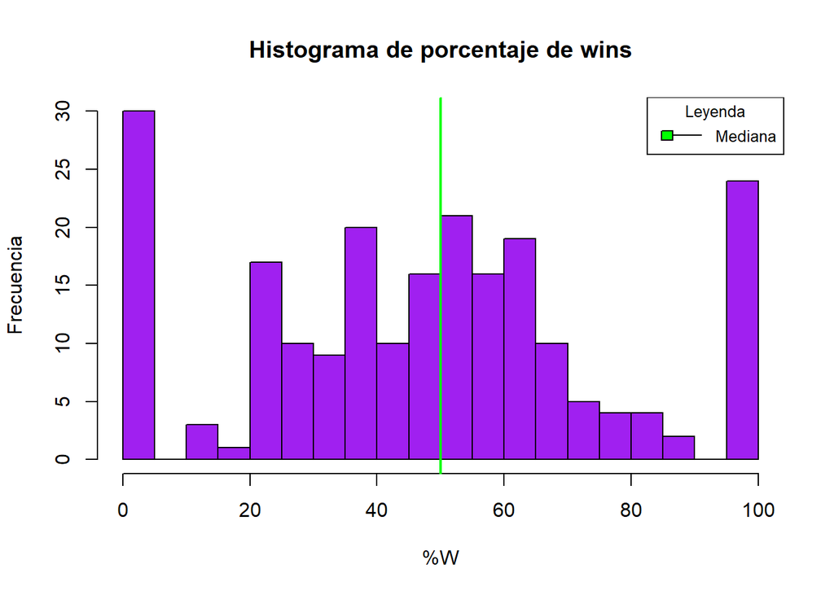

```r
hist(DF2$`W%`,breaks=20,col=c("purple"),main="Histograma de porcentaje de wins",xlab="%W",ylab="Frecuencia")
abline(v=median(DF2$`W%`),col="green",lwd=2)
legend("topright",
       c("Mediana"),
       lty=1,
       fill =c("green"),
       bty = "o", title="Leyenda",bg="transparent",cex=0.8)
```

Análisis: Independientemente de la posición de los jugadores se puede concluir que los valores están relativamente distribuidos alrededor de la mediana.

=======================================================================================

## 3. Análisis Inferencial

=======================================================================================

## 3.1 ¿Tener un alto KDA te garantiza un gran porcentaje de victorias?

### Planteamiento:

```r
DFadc<-which(DF2$Pos=="ADC")
DFtop<-which(DF2$Pos=="Top")
DFjg<-which(DF2$Pos=="Jungle")
DFmid<-which(DF2$Pos=="Middle")
DFsupp<-which(DF2$Pos=="Support")
```

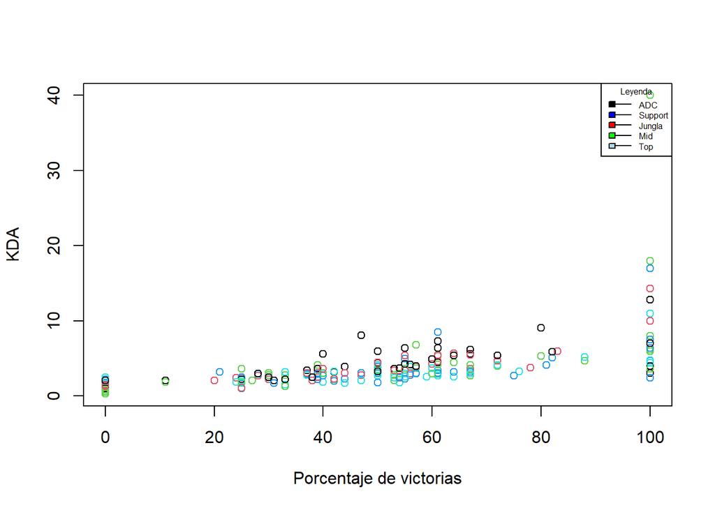

```r
plot(DF2$KDA ~ DF2$`W%`, ylab='KDA', xlab='Porcentaje de victorias',col = as.factor(DF2$Pos))
legend("topright",
       c("ADC","Support","Jungla","Mid","Top"),
       lty=1,
       fill =c("black","blue","red","green","lightblue"),
       bty = "o", title="Leyenda",bg="transparent",cex=0.51)
```

- Análisis: Relación proporcional entre el KDA y el porcentaje de victoria de los jugadores, algo convenientemente lógico dado la ventaja que puede obtener un equipo de su rival.Con algunas diferencias significativas entre posiciones. Las posiciones no determinan el nivel de habilidad pero ciertamente algunas tienen más ventajas sobre otras para obtener kills y reducir el número de muertes, variables de las que se obtiene el KDA, explicando estos valores tan altos.

¿Si una posición (ADC) tiene KDA alto, el jugador tiene más victorias?

```r
DF2 %>% filter(GP>=10)->DFGPok
DFPokadc<-which(DFGPok$Pos=="ADC")
DFPoktop<-which(DFGPok$Pos=="Top")
DFPokjg<-which(DFGPok$Pos=="Jungle")
DFPokmid<-which(DFGPok$Pos=="Middle")
DFPoksupp<-which(DFGPok$Pos=="Support")
```

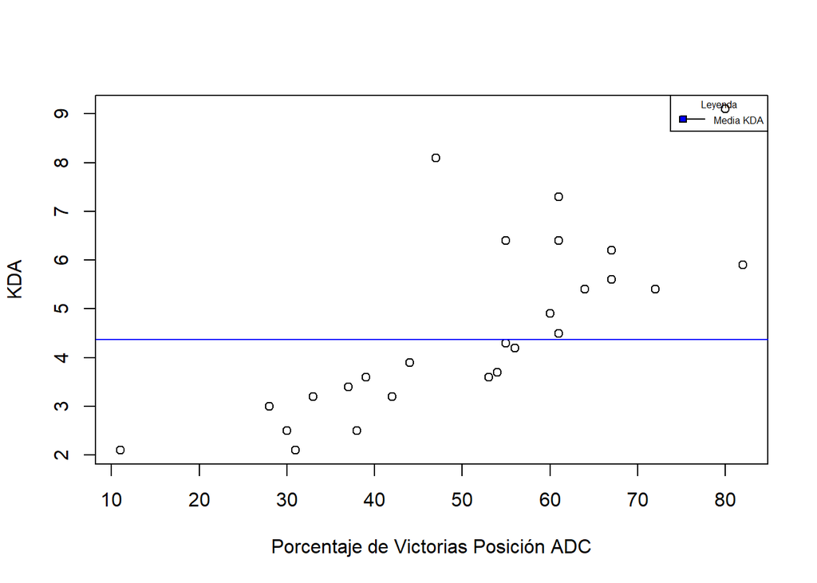

```r
plot(DFGPok[DFPokadc,]$`KDA` ~ DFGPok[DFPokadc,]$`W%`,ylab="KDA",xlab="Porcentaje de Victorias Posición ADC")
abline(h=mean(DF2[DFadc,]$`KDA`),col="blue")
legend("topright",
       c("Media KDA"),
       lty=1,
       fill =c("blue"),
       bty = "o", title="Leyenda",bg="transparent",cex=0.51)
```

- Hipótesis: El rol del ADC es hacer el mayor número de kills a los rivales. En la gráfica se evidencia que entre mayor sea su habilidad o KDA, mayor es el porcentaje de victorias del jugador y por tanto de su equipo. Podemos deducir entonces que los mejores jugadores superan un valor cercano a la media, el cual puede establecerse como 5 por ejemplo.

## 3.2 ¿Existe una relación entre el porcentaje de muertes de un jugador y el porcentaje de daño que realiza?

### –Planteamiento–

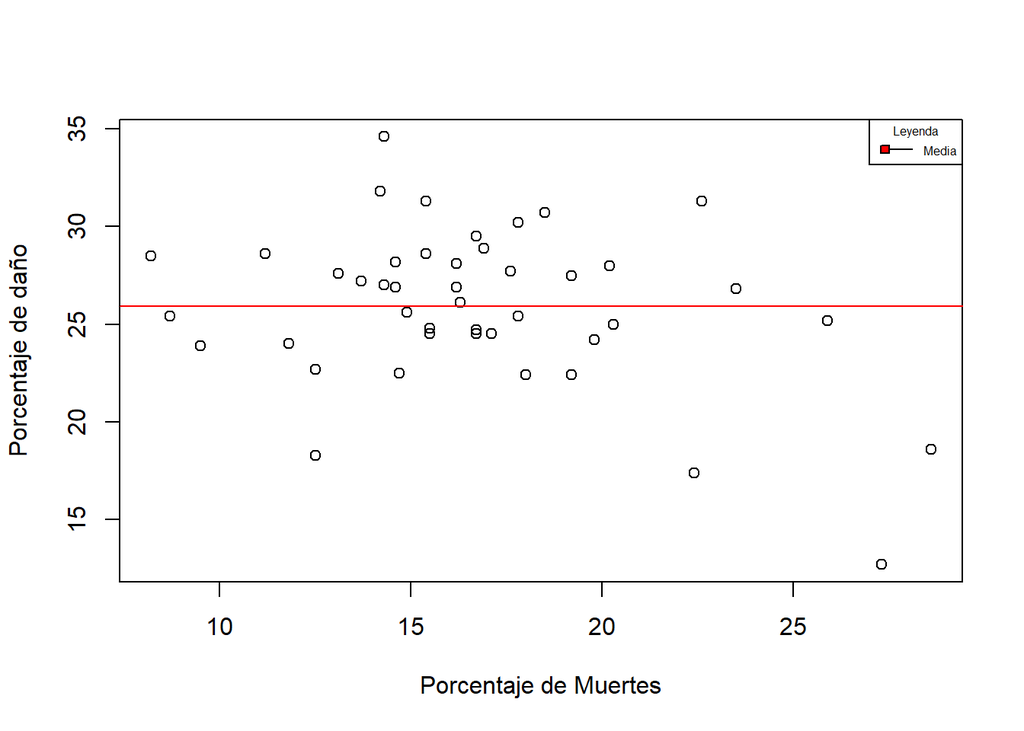

```r
plot(DF2[DFadc,]$`DMG%` ~ DF2[DFadc,]$`DTH%`,ylab="Porcentaje de daño",xlab="Porcentaje de Muertes")
abline(h=mean(DF2[DFadc,]$`DMG%`),col="red")
legend("topright",
       c("Media"),
       lty=1,
       fill =c("red"),
       bty = "o", title="Leyenda",bg="transparent",cex=0.51)
```

Hipótesis: Se plantea entonces, que tener un porcentaje elevado del daño que aplicaste no significa haber tenido un pequeño porcentaje de muertes durante la partida.

## 3.3 ¿Hay una influencia en el porcentaje de oro obtenido a mayor número de súbditos por minuto?

### –Planteamiento–

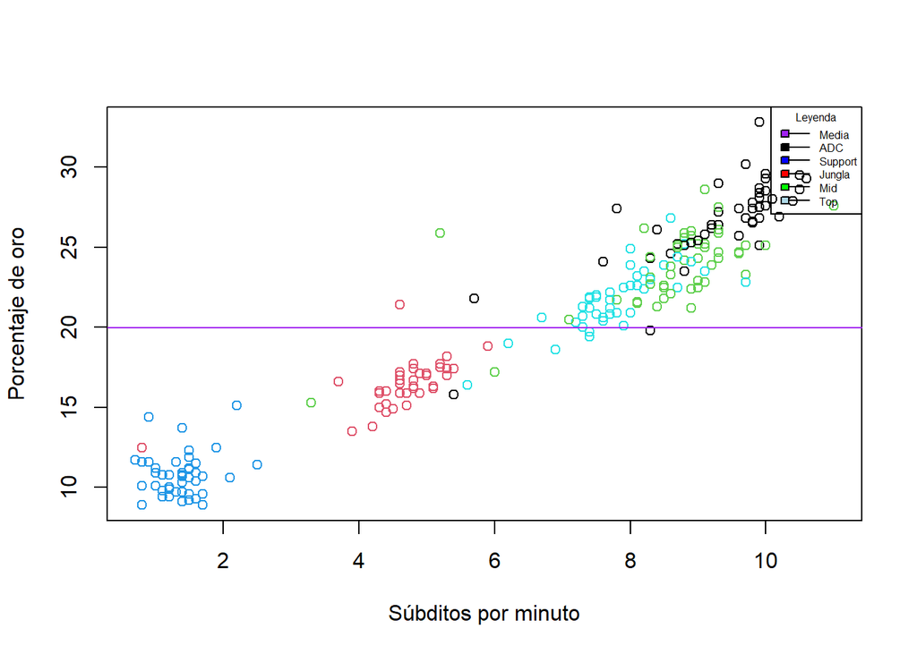

```r
plot(DF2$`Gold%` ~ DF2$CSPM,ylab="Porcentaje de oro",xlab="Súbditos por minuto",col = as.factor(DF2$Pos) )
abline(h=mean(DF2$`Gold%`),col="purple")
legend("topright",
       c("Media","ADC","Support","Jungla","Mid","Top"),
       lty=1,
       fill =c("purple","black","blue","red","green","lightblue"),
       bty = "o", title="Leyenda",bg="transparent",cex=0.51)
```

- Análisis: Se observa un escalado general de la relación entre el porcentaje de oro y los súbditos por minuto para cada posición, a excepción de Support.Por otro lado algunas posiciones tienen mayor linealidad en sus datos que otras. Como las posiciones Jungla y ADC respectivamente.
- Hipótesis: El oro se obtiene a través de los súbditos entre otros enemigos, a mayor número ,mayor recaudación. Se plantea entonces una relación directa, entre más CSPM tengas, mayor es el porcentaje de oro obtenido. En concreto se observan valores más altos para la posición ADC, posición que por lo general realiza más daño y kills en el equipo.

## 3.4 ¿Tener muchas asistencias determina un alto porcentaje de victorias?

### –Planteamiento–

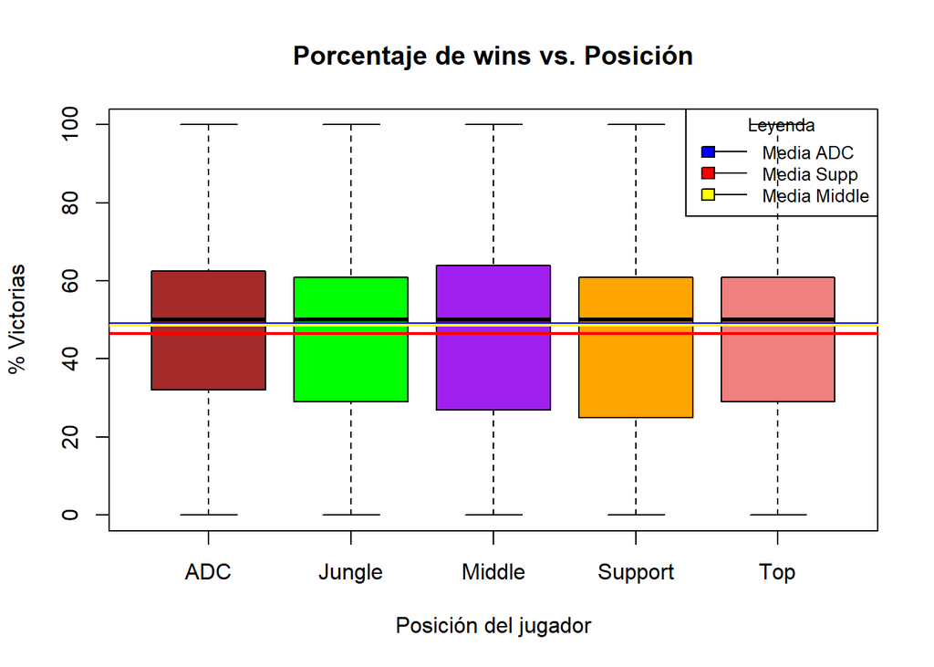

```r
boxplot(DF2$`W%` ~ DF2$Pos,main="Porcentaje de wins vs. Posición",xlab="Posición del jugador",ylab="% Victorias",col=c("brown","green","purple","orange","lightcoral"))
abline(h=mean(DF2[DFadc,]$`W%`),col="blue",lwd=2)
abline(h=mean(DF2[DFsupp,]$`W%`),col="red",lwd=2)
abline(h=mean(DF2[DFmid,]$`W%`),col="yellow",lwd=2)
legend("topright",
       c("Media ADC","Media Supp","Media Middle"),
       lty=1,
       fill =c("blue","red","yellow"),
       bty = "o", title="Leyenda",bg="transparent",cex=0.8)
```

- Análisis: Se aprecia una diferencia poco significativa entre la media del porcentaje de victorias del ADC y del Support; lo que quiere decir que independientemente del rol seleccionado, cada posición tiene un número similar de victorias.

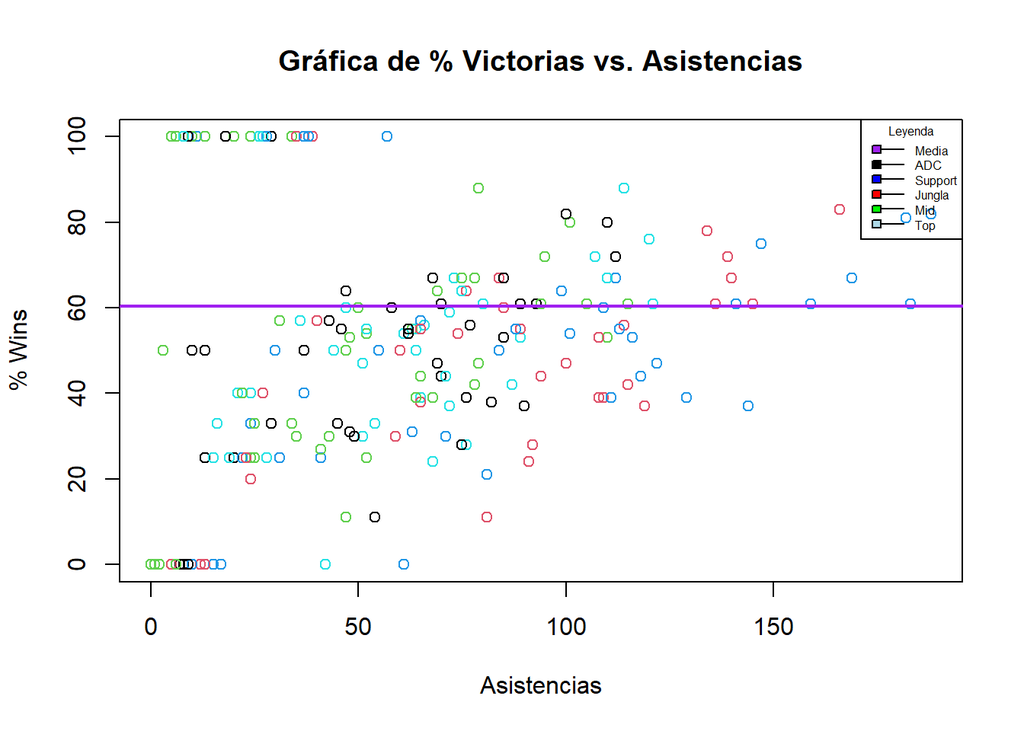

```r
plot(DF2$`W%` ~ DF2$A, main="Gráfica de % Victorias vs. Asistencias",ylab="% Wins",xlab="Asistencias",col = as.factor(DF2$Pos) )
abline(h=mean(DF2$A),col="purple",lwd=2)
legend("topright",
       c("Media","ADC","Support","Jungla","Mid","Top"),
       lty=1,
       fill =c("purple","black","blue","red","green","lightblue"),
       bty = "o", title="Leyenda",bg="transparent",cex=0.51)
```

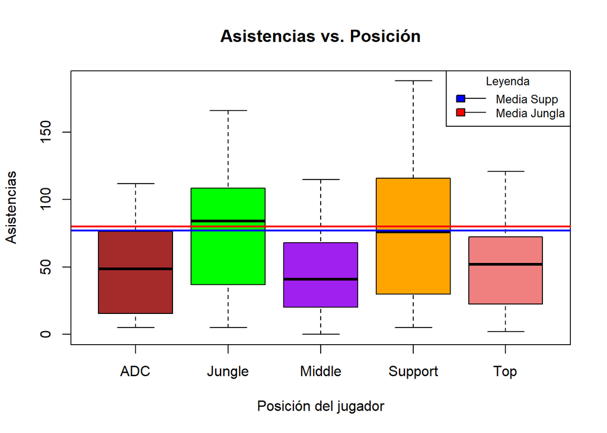

```r
boxplot(DF2$A ~ DF2$Pos,main="Asistencias vs. Posición",xlab="Posición del jugador",ylab="Asistencias",col=c("brown","green","purple","orange","lightcoral"))
abline(h=mean(DF2[DFsupp,]$A),col="red",lwd=2)
abline(h=mean(DF2[DFjg,]$A),col="blue",lwd=2)
legend("topright",
       c("Media Supp","Media Jungla"),
       lty=1,
       fill =c("blue","red"),
       bty = "o", title="Leyenda",bg="transparent",cex=0.8)
```

- Hipótesis: Se aprecia que la media de Asistencias de la posición Support y Jungla son muy similares a diferencia del resto de posiciones. Explicando que ambos tienen un rol similar en el equipo, el cual es apoyar, pero desempeñados de manera distinta. Se plantea entonces que la media de las asistencias del Support es mayor que el resto de posiciones.

=======================================================================================

## 4. Intervalos de confianza

=======================================================================================

#### Muestra: Se trabaja con una muestra de tamaño 221, jugadores participantes del torneo.

#### Nivel de confianza: Se toma un nivel de confianza del 95%. Considerado un porcentaje recomendado en proyectos y estudios similares.

#### Nivel de signifcancia: Se toma entonces una significancia de 0.05. Dado por la ecuación 1 − α = nivel de confianza.

```r
n=221
alfa=0.05
z<-qnorm(alfa/2,lower.tail = FALSE)
```

4.1 Intervalos de confianza para la media de KDA

```r
xt=mean(DF2$KDA)
st=sd(DF2$KDA)

le<- xt - z*st/sqrt(n)
ri<- xt + z*st/sqrt(n)
cat("(",le,",",ri,")\n")
```

```
## ( 3.290811 , 4.206021 )
```

4.2 Intervalos de confianza para la media de porcentaje de victorias

```r
xt2=mean(DF2$`W%`)
st2=sd(DF2$`W%`)

le2<- xt2 - z*st2/sqrt(n)
ri2<- xt2 + z*st2/sqrt(n)
cat("(",le2,",",ri2,")\n")
```

```
## ( 43.89659 , 51.44278 )
```

Intervalo de confianza para:
$$Porcentaje Wins =[44 , 52 ]$$

4.3 Intervalos de confianza para la media de “súbditos por minuto”

```r
xt3=mean(DF2$CSPM)
st3=sd(DF2$CSPM)

le3<- xt3 - z*st3/sqrt(n)
ri3<- xt3 + z*st3/sqrt(n)
cat("(",le3,",",ri3,")\n")
```

```
## ( 5.977507 , 6.801679 )
```

Intervalo de confianza para:
$$Porcentaje
Súbditos por minuto =[6 , 7 ]$$

4.4 Intervalos de confianza para la media del porcentaje de daño

```r
xt4=mean(DF2$`DMG%`)
st4=sd(DF2$`DMG%`)

le4<- xt4 - z*st4/sqrt(n)
ri4<- xt4 + z*st4/sqrt(n)
cat("(",le4,",",ri4,")\n")
```

```
## ( 18.93673 , 20.97368 )
```

Intervalo de confianza para:
$$Porcentaje
Daño =[19 , 21 ]$$

4.5 Intervalos de confianza para la media porcentaje de muertes

```r
xt5=mean(DF2$`DTH%`)
st5=sd(DF2$`DTH%`)

le5<- xt5 - z*st5/sqrt(n)
ri5<- xt5 + z*st5/sqrt(n)
cat("(",le5,",",ri5,")\n")
```

```
## ( 18.992 , 20.54284 )
```

Intervalo de confianza para:
$$Porcentaje
Muertes =[19 , 21 ]$$

4.6 Intervalos de confianza para la media porcentaje de oro

```r
xt6=mean(DF2$`Gold%`)
st6=sd(DF2$`Gold%`)

le6<- xt6 - z*st6/sqrt(n)
ri6<- xt6 + z*st6/sqrt(n)
cat("(",le6,",",ri6,")\n")
```

```
## ( 19.15726 , 20.76129 )
```

=======================================================================================

## 5. Variables aleatorias

=======================================================================================

### 5.1 Variables aleatorias discretas

### Porcentaje de victorias:

```r
summary(DF2$`W%`)
```

```
##    Min. 1st Qu.  Median    Mean 3rd Qu.    Max.
##    0.00   30.00   50.00   47.67   61.00  100.00
```

```r
sdw<-sd(DF2$`W%`)
sdw
```

```
## [1] 28.61841
```

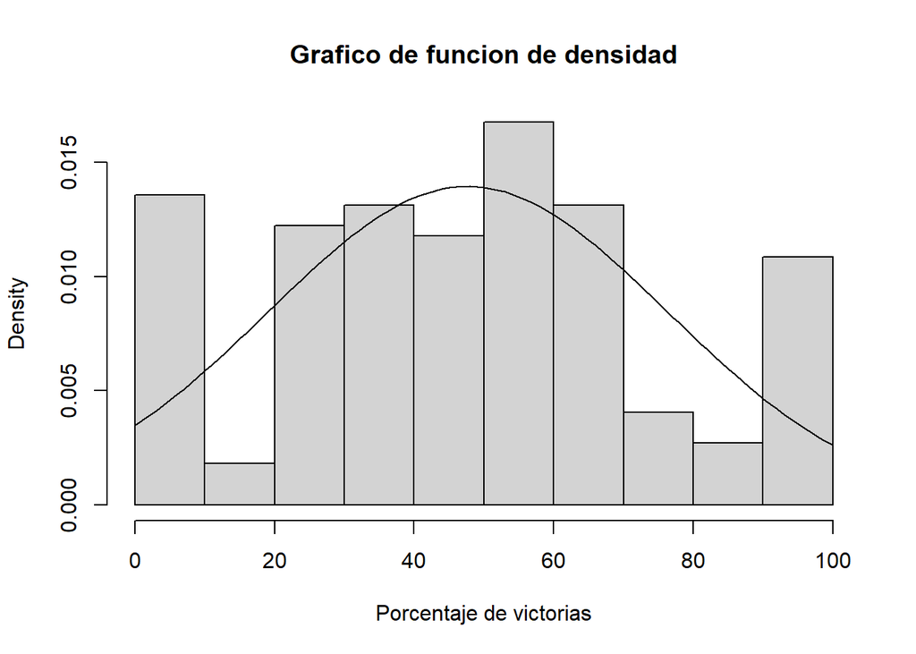

```r
hist(DF2$`W%`, freq = F,main = "Grafico de funcion de densidad", xlab = "Porcentaje de victorias")
curve(dnorm(x, mean = 47.67, sd = sdw), from = 0, to = 100, add = TRUE)
```

### Variable Posición ADC

- Variable aleatoria binomial: Búsqueda de la probabilidad que del total de jugadores, 44 sean de la posición ADC.

```r
numADC=sum(DF2$Pos=="ADC")
numADC
```

```
## [1] 44
```

- Probabilidad de éxito: p= Probabilidad de que un jugador sea ADC

```r
padc=numADC/nrow(DF2)
padc
```

```
## [1] 0.199095
```

- Probabilidad de fracaso: probabilidad de que un jugador no sea ADC

```r
1-padc
```

```
## [1] 0.800905
```

- Función de probabilidad:

```r
round(dbinom(44,n,padc),2)
```

```
## [1] 0.07
```

- Esperanza:

```r
n*padc
```

```
## [1] 44
```

### Variable CSPM

```r
summary(DF2$CSPM)
```

```
##    Min. 1st Qu.  Median    Mean 3rd Qu.    Max.
##    0.70    4.40    7.70    6.39    8.90   11.00
```

```r
sdw1<-sd(DF2$CSPM)
sdw1
```

```
## [1] 3.125617
```

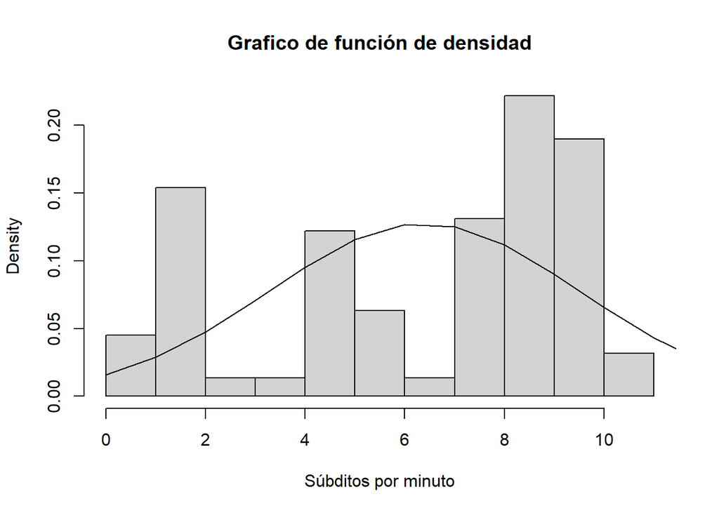

```r
hist(DF2$CSPM, freq = F,main = "Grafico de función de densidad", xlab = "Súbditos por minuto")
curve(dnorm(x, mean = 6.39, sd = sdw1),from = 0,to = 100, add = TRUE)
```

```r
summary(DF2$`DMG%`)
```

```
##    Min. 1st Qu.  Median    Mean 3rd Qu.    Max.
##    5.40   12.70   22.50   19.96   26.10   47.90
```

```r
sdw2<-sd(DF2$`DMG%`)
sdw2
```

```
## [1] 7.724985
```

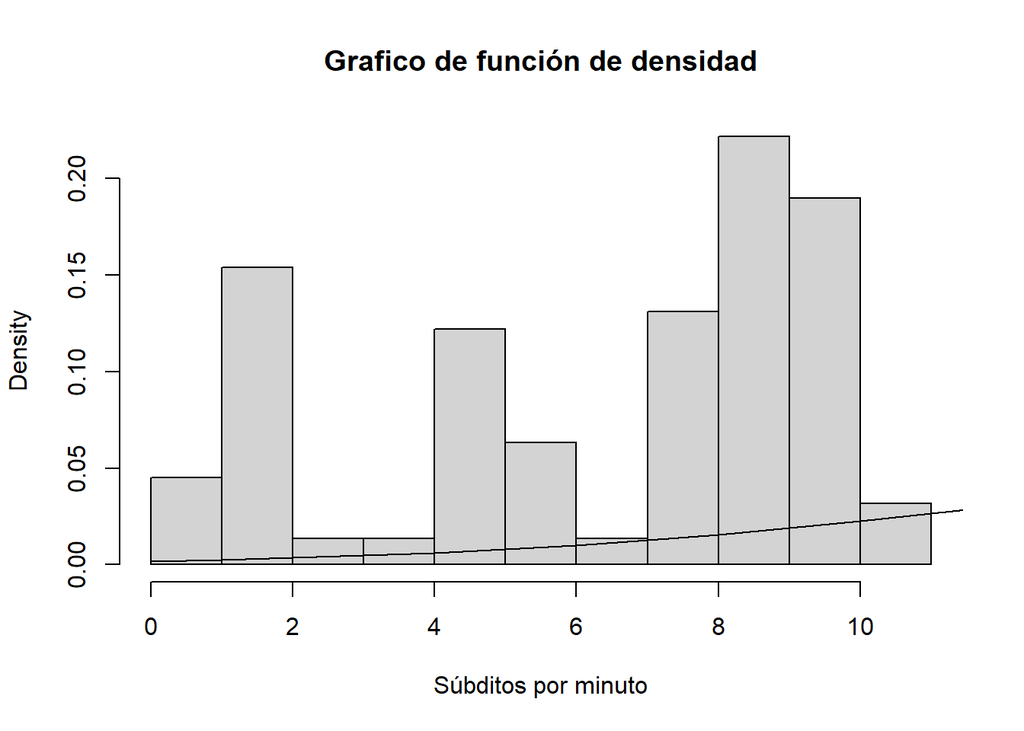

```r
hist(DF2$CSPM, freq = F,main = "Grafico de función de densidad", xlab = "Súbditos por minuto")
curve(dnorm(x, mean = 19.96, sd = sdw2),from = 0,to = 100, add = TRUE)
```

=======================================================================================

## 6. Prueba de hipotesis

=======================================================================================

$$Confianza = 0.95$$
$$Significancia = 0.05$$
$$Tamaño-Muestra-Variable
="n"$$

## 6.1.”KDA” media del porcentaje de victorias para la posición ADC.

- Hipótesis: En la gráfica previamente mostrada se evidencia que entre mayor sea su habilidad o KDA, mayor es el porcentaje de victorias del jugador. Podemos deducir entonces que los mejores ADC están por encima de la media de KDA del porcentaje de victorias ADC. Se toma 5 como valor la hipótesis al ser el valor entero más cercano al promedio real.
- Tamaño de la muestra solo para la posición ADC, n=“26”
- H0:El KDA promedio del porcentaje de victorias de la posición ADC es >= 5
- H1:El KDA promedio del porcentaje de victorias de la posición ADC es < 5

```r
DFadc<-read.csv("data_adc.csv" )
summary(DFadc$KDA)
```

```
##    Min. 1st Qu.  Median    Mean 3rd Qu.    Max.
##   2.100   3.250   4.250   4.635   5.825   9.100
```

```r
est<-(4.635-5)/sd(DFadc$KDA)/nrow(DFadc)
tcritico <- qt(0.05, df = 25)
pvalor<-pt(est, df=25)
```

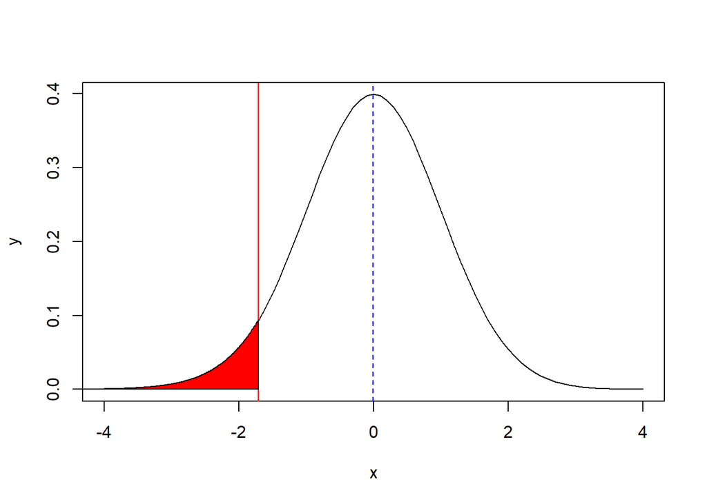

```r
x <- seq(-4, 4, by = 0.1)
y <- dnorm(x)
plot(x, y, type="l")
abline(v=c(tcritico,est), lty = c(1,2), col = c("red", "blue"))
coorx1 <- c(-10, seq(-10, -1.708141, 0.01), -1.708141)
coory1 <- c(0, dt(seq(-10, -1.708141, 0.01), 25), 0)
polygon(coorx1, coory1, col = "red")
```

Resultados:

- No se rechaza la hipótesis nula (p-valor>0.05).
- Estadístico de prueba fuera de la región de rechazo.

## 6.2. Media de la variable porcentaje de oro generado para los “súbditos por minuto”.

- Hipótesis: El oro se obtiene a través de los súbditos entre otros enemigos, a mayor número , mayor recaudación. Se plantea entonces de la gráfica previa, una relación directa, entre más Súbditos por minutos generes (“CSPM”), mayor es el porcentaje de oro obtenido. Tomamos como referencia 20, el valor promedio del porcentaje de oro más cercano al real.
- Tamaño de la muestra “n=221” : Se incluyen a todos los jugadores participantes.
- H0:El promedio de porcentaje de oro es >= 20.
- H1:El promedio de porcentaje de oro es < 20.

```r
summary(DF2$`Gold%`)
```

```
##    Min. 1st Qu.  Median    Mean 3rd Qu.    Max.
##    8.90   15.30   21.40   19.96   25.00   32.80
```

```r
est2<-(19.96-20)/sd(DF2$`Gold%`)/nrow(DF2)
zcritico <- qnorm(0.05)
pvalor2<-pnorm(est2)
cat("(",zcritico,",",pvalor2,")\n")
```

```
## ( -1.644854 , 0.4999881 )
```

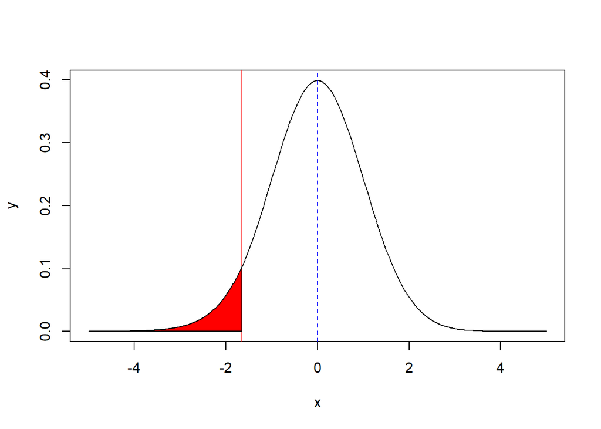

```r
x <- seq(-5, 5, by = 0.1)
y <- dnorm(x)
plot(x, y, type="l")
abline(v=c(zcritico,est2), lty = c(1,2), col = c("red", "blue"))
coordenada4.x1 <- c(-4.5, seq(-4.5, zcritico, 0.01), zcritico)
coordenada4.y1 <- c(0, dt(seq(-4.5, zcritico, 0.01), 25), 0)
polygon(coordenada4.x1, coordenada4.y1, col = "red")
```

Resultados:

- No se rechaza la hipótesis nula (p-valor>0.05).
- Estadístico de prueba fuera de la región de rechazo.

## 6.3. Determinar la relevancia del número de asistencias siendo de la posición Support.

```r
DFadcsupp<-read_csv("ADC-SUPP.csv")
```

```
## -------------------------------------------------------- Delimiter: "," chr
## (4): Player, Team, Pos, Split dbl (21): ...1, GP, W%, K, D, A, KDA, KP, DTH%,
## FB%, GD10, XPD10, CSD10, CSP...
```

```r
DFsupp2<-read.csv("Suppdata.csv")
summary(DFadcsupp$A)
```

```
##    Min. 1st Qu.  Median    Mean 3rd Qu.    Max.
##   45.00   69.50   89.00   96.96  114.50  188.00
```

```r
est3<-(96.96-100)/sd(DFadcsupp$A)/nrow(DFadcsupp)
zcritico2 <- qnorm(0.05)
pvalor3<-pnorm(est3)
cat("(",zcritico2,",",pvalor3,")\n")
```

```
## ( -1.644854 , 0.4993637 )
```

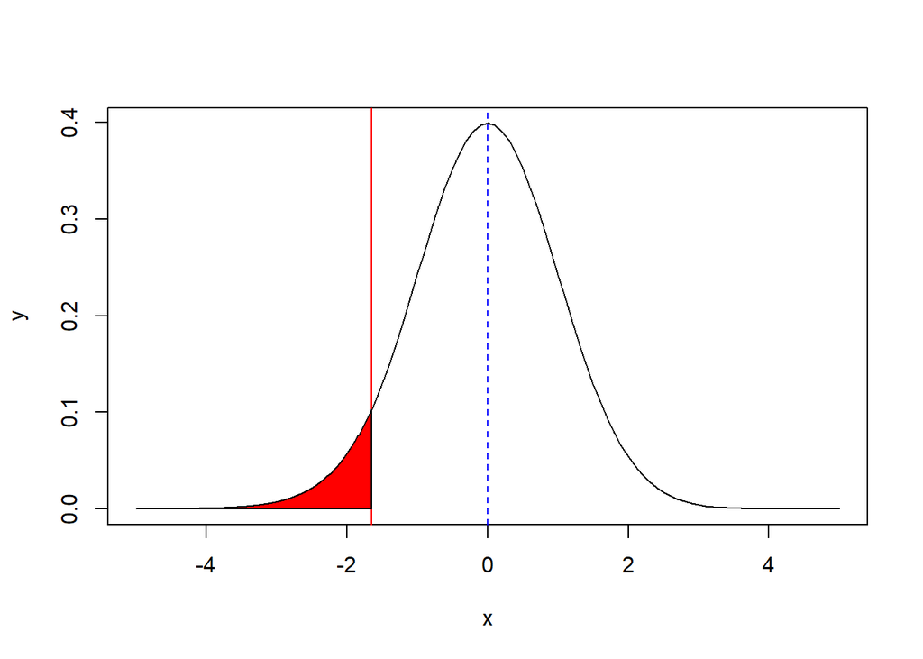

```r
x <- seq(-5, 5, by = 0.1)
y <- dnorm(x)
plot(x, y, type="l")
abline(v=c(zcritico2,est3), lty = c(1,2), col = c("red", "blue"))
coordenada4.x1 <- c(-4.5, seq(-4.5, zcritico2, 0.01), zcritico2)
coordenada4.y1 <- c(0, dt(seq(-4.5, zcritico2, 0.01), 25), 0)
polygon(coordenada4.x1, coordenada4.y1, col = "red")
```

Resultados: - No se rechaza la hipótesis nula (p-valor>0.05).

- Estadístico de prueba fuera de la región de rechazo.

=======================================================================================

## 7. Regresión y predicciones

=======================================================================================

## 7.1 KDA del porcentaje de victorias para ADC

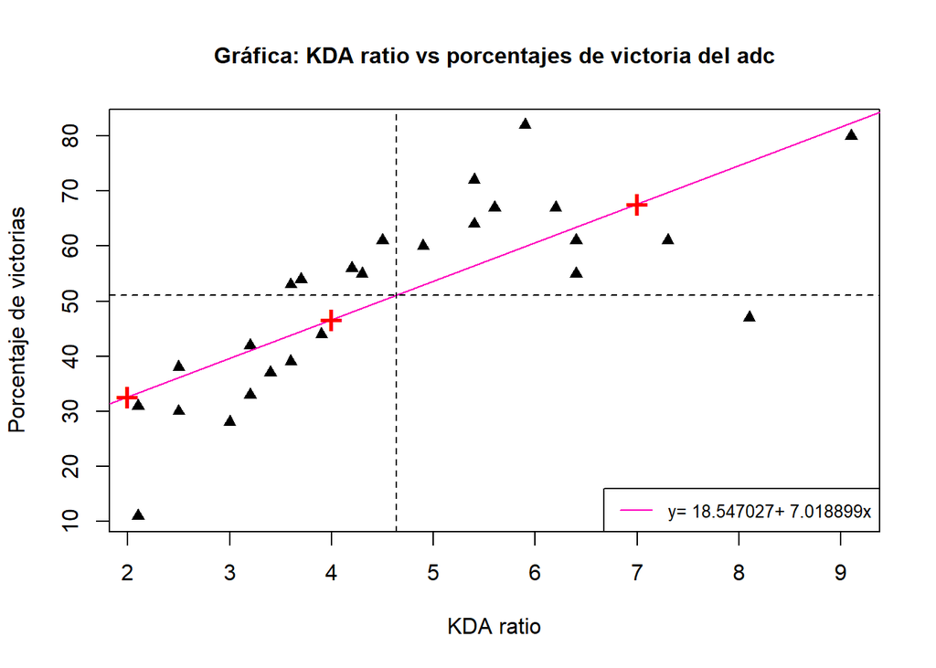

```r
plot(DFadc$W. ~ DFadc$KDA  ,ylab ="Porcentaje de victorias" , xlab ="KDA ratio" , main = "Gráfica: KDA ratio vs porcentajes de victoria del adc", pch = 17, cex.axis = 1,cex.main = 1)
legend("bottomright",legend=c("y= 18.547027+ 7.018899x"),col = "#FF00BE",lty=1:2, cex=0.8)

abline(lm(DFadc$W. ~ DFadc$KDA), col = "#FF00BE")
abline(h = mean(DFadc$W.), lty = "dashed")
abline(v = mean(DFadc$KDA), lty = "dashed")
text(x = c(7, 4, 2),
     y = c(67.67932, 46.622623, 32.584825),
     labels = c("+", "+", "+"),cex = 2,col="red")
```

```r
Reg_1<-lm(DFadc$W. ~ DFadc$KDA)
summary(Reg_1)
```

```
##
## Call:
## lm(formula = DFadc$W. ~ DFadc$KDA)
##
## Residuals:
##      Min       1Q   Median       3Q      Max
## -28.4001  -5.9235  -0.4641   7.8679  22.0415
##
## Coefficients:
##             Estimate Std. Error t value Pr(>|t|)
## (Intercept)   18.547      6.116   3.033  0.00574 **
## DFadc$KDA      7.019      1.229   5.712 6.94e-06 ***
## ---
## Signif. codes:  0 '***' 0.001 '**' 0.01 '*' 0.05 '.' 0.1 ' ' 1
##
## Residual standard error: 11.37 on 24 degrees of freedom
## Multiple R-squared:  0.5762, Adjusted R-squared:  0.5585
## F-statistic: 32.63 on 1 and 24 DF,  p-value: 6.941e-06
```

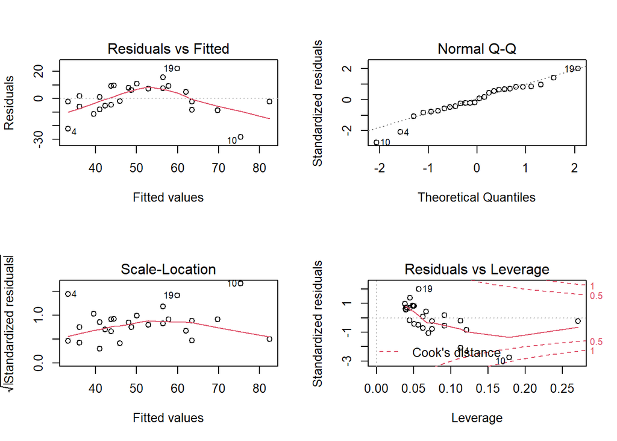

```r
par(mfrow=c(2,2))
plot(Reg_1)
```

Análisis:

- El modelo muestra coeficientes significativos, en concreto el P-value siendo menor a la significancia establecida como 5%, estos pueden predecir confiablemente al porcentaje de victorias. Sin embargo solo puede describir 57.62% de la variaciones del porcentaje de victoria.
- Hay mucha dispersión de los residuos entre distintos rangos, de los cuales se presenta poca homocedasticidad.Y existe problemas con la linealidad de nuestra relación.
- Los residuos son un poco más pequeños en la cola derecha de lo que esperaríamos ver de acuerdo a la teoría.
- Scale vs Location: sugiere que la varianza de los errores no es constante, existe heterocedasticidad.
- Algunos elementos poseen un efecto palanca en el modelo.

Conclusión: Se rechaza el modelo de regresión KDA y porcentaje de victorias

## 7.2 Promedio de porcentaje de oro vs Subditos por minuto

```r
DFprueba<-read.csv("PruebaReg.csv")
```

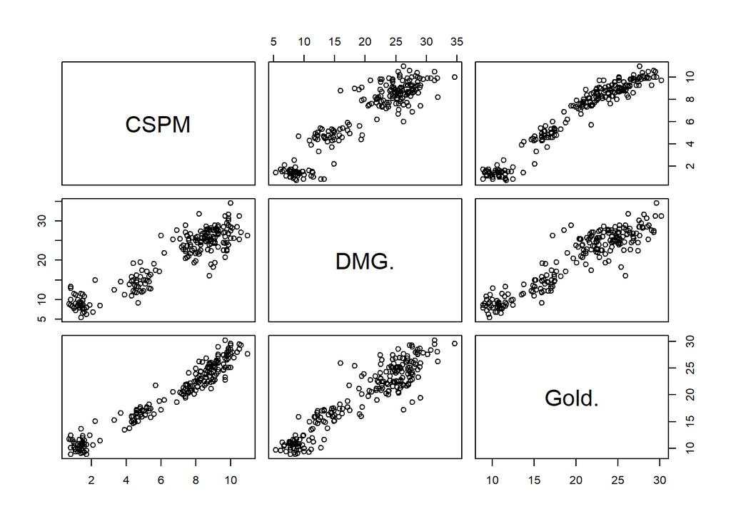

```r
plot(DFprueba)
```

Análisis:

- El porcentaje de oro puede depender de diferentes variables, decidimos usar porcentaje de daño y súbditos por minuto. De plot(DFprueba)encontramos una correlación entre porcentaje de oro y porcentaje de daño o súbditos por minuto, por lo que pueden ser predictores razonables para el porcentaje de oro. Además también existe una relación entre porcentaje de daño y súbditos por minuto, lo que puede significar que no sea necesario usar las dos.

```r
mulreg<-lm(DFprueba$Gold.~DFprueba$DMG.+DFprueba$CSPM)
summary(mulreg)
```

```
##
## Call:
## lm(formula = DFprueba$Gold. ~ DFprueba$DMG. + DFprueba$CSPM)
##
## Residuals:
##     Min      1Q  Median      3Q     Max
## -3.3353 -0.8691 -0.0833  0.8321  3.5623
##
## Coefficients:
##               Estimate Std. Error t value Pr(>|t|)
## (Intercept)    7.02549    0.27244  25.787  < 2e-16 ***
## DFprueba$DMG.  0.14603    0.03239   4.509 1.08e-05 ***
## DFprueba$CSPM  1.55068    0.07812  19.849  < 2e-16 ***
## ---
## Signif. codes:  0 '***' 0.001 '**' 0.01 '*' 0.05 '.' 0.1 ' ' 1
##
## Residual standard error: 1.327 on 211 degrees of freedom
## Multiple R-squared:  0.9522, Adjusted R-squared:  0.9518
## F-statistic:  2103 on 2 and 211 DF,  p-value: < 2.2e-16
```

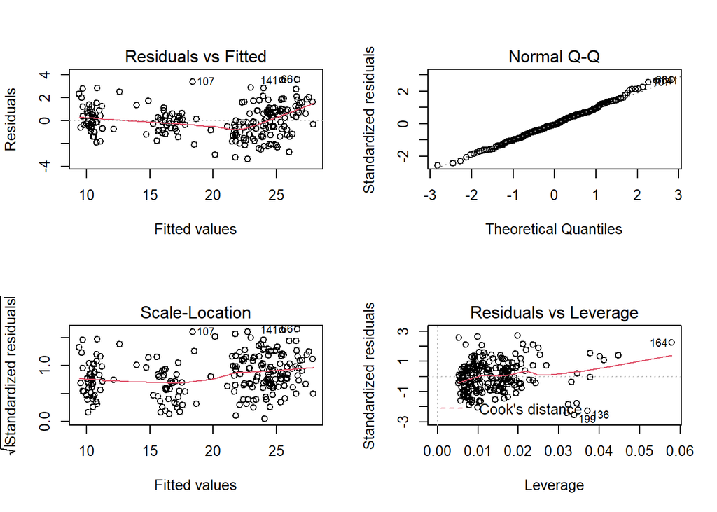

```r
par(mfrow=c(2,2))
plot(mulreg)
```

Análisis:

- Los p-valores en summary(mulreg), son significativos tanto para describir el porcentaje de oro en base al daño ajustando por promedio de Súbditos por minuto o describir el porcentaje de oro en base al promedio de Súbditos por minuto ajustando por el porcentaje de daño. Sin embargo la segunda al ser más significativa describe mejor el porcentaje de oro si usamos las dos variables independientes en vez de solo promedio de súbditos por minuto.
- El modelo “Promedio de porcentaje de oro= Intercepto + (pendiente1* D%)+(pendiente2 * CSPM)” podría ser usado, después de analizar el diagnostico de regresión.
- Residuals vs Fitted: Se puede asumir un patrón linear. Scale vs Location: Presenta heterocedasticidad leve. . Residuals vs Leverage: Existen puntos atípicos con influencia en la regresión, pero todos los puntos están dentro de las líneas de Cook.

Conclusión: No se rechaza el modelo de regresión porcentaje de oro en base al promedio de Súbditos por minuto ajustando por el porcentaje de daño “Promedio de porcentaje de oro= Intercepto + (pendiente1 * D%)+(pendiente2 * CSPM)”

## 7.3 Asistencias del Support y el Porcentaje de victorias

```r
DFsupp2<-read.csv("Suppdata.csv")
```

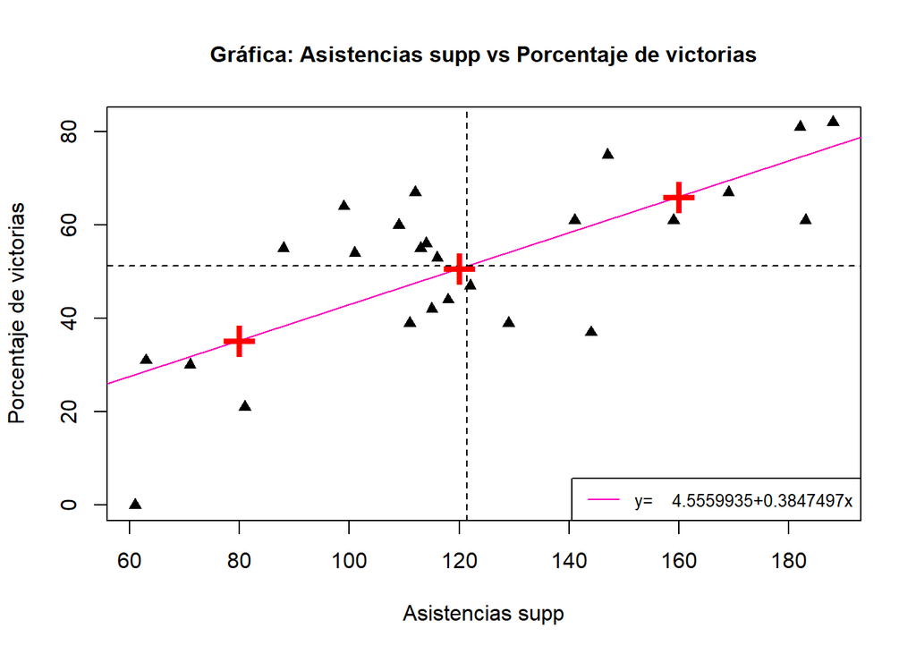

```r
plot(DFsupp2$W.~DFsupp2$A  ,ylab = "Porcentaje de victorias", xlab = "Asistencias supp", main = "Gráfica: Asistencias supp vs Porcentaje de victorias", pch = 17, cex.axis = 1, cex = 1, cex.main = 1)

## Linea de regresión
abline(lm(DFsupp2$W.~DFsupp2$A), col = "#FF00BE")
abline(h = mean(DFsupp2$W.), lty = "dashed")
abline(v = mean(DFsupp2$A), lty = "dashed")
legend("bottomright",legend=c("y=    4.5559935+0.3847497x"),col = "#FF00BE",lty=1:2, cex=0.8)
text(x = c(160, 120, 80),
     y = c(66.1159455, 50.7259575, 35.3359695),
     labels = c("+", "+", "+"),cex = 3,col="red")
```

```r
Reg_2<-lm(DFsupp2$W.~DFsupp2$A)
summary(Reg_2)
```

```
##
## Call:
## lm(formula = DFsupp2$W. ~ DFsupp2$A)
##
## Residuals:
##     Min      1Q  Median      3Q     Max
## -28.026  -6.802   2.194   7.582  21.354
##
## Coefficients:
##             Estimate Std. Error t value Pr(>|t|)
## (Intercept)   4.5560     9.4074   0.484    0.633
## DFsupp2$A     0.3847     0.0744   5.171 3.05e-05 ***
## ---
## Signif. codes:  0 '***' 0.001 '**' 0.01 '*' 0.05 '.' 0.1 ' ' 1
##
## Residual standard error: 13.1 on 23 degrees of freedom
## Multiple R-squared:  0.5376, Adjusted R-squared:  0.5175
## F-statistic: 26.74 on 1 and 23 DF,  p-value: 3.052e-05
```

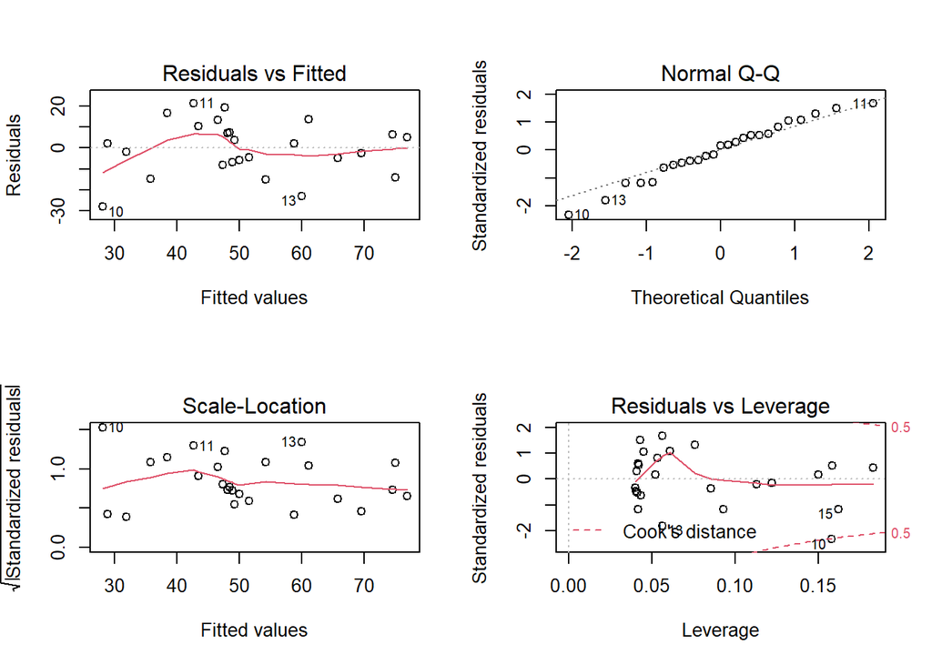

```r
par(mfrow=c(2,2))
plot(Reg_2)
```

Análisis:

- El p-value encontrado en summary(reg2) nos indica que el coeficiente de asistencias es suficientemente significativo al 5% para describir un modelo de regresión. Sin embargo solo puede describir 53.76% de la variaciones del porcentaje de victoria para el rol Supp.
- Tomando en cuenta el diagnostico de regresión. Residuals vs Fitted: Existe un patrón no linear. Scale vs Location: sugiere que la varianza de los errores no es constante, existe heterocedasticidad. Residuals vs Leverage: Aunque las líneas de Cook aparecen en la gráfica, los valores atípicos de los que se nos advierte, como el punto 10, no son muy influyentes en el modelo de regresión, ya que se mantienen en el rango de residuos estandarizados.

Conclusión: Se rechaza el modelo de regresión asistencias y porcentaje de victorias de rol soporte

=======================================================================================

# 8. Conclusiones

=======================================================================================